# R Notebook

Jasmin_Baghiana

7/28/2022

# Einleitung

Ende 2017 leiten Schauspielerinnen aus Holllywood Belästigungsvorwürfe gegenüber Harvey Weinstein ein, die unter dem Hashtag #metoo eine globale Debatte ins Rollen bringen sollte.¹ Jede, die selbst sexuell übergriffige Handlungen erlebt hat, solle dies der Welt kundtun.Nachdem dieser Hashtag unter anderem auf Twitter viral geht, findet er auch im deutschen Raums des sozialen Netzwerks Gebrauch. Bis zu jenem Zeitpunkt wurde eher Stillschweigen statt Sühne der Täter*(innen) gepredigt. Mit dem Anstoß der Enttabuisierung und des Bekanntmachens eines sexistischen Machtmissbrauchsystems beginnt eine neue Ära des Feminismus.

Diese Analyse soll sich um die Frage drehen: wer sind zu Beginn der #Metoo Debatte (15.10.2017) in Deutschland die führenden Accounts auf der Plattform Twitter? Besonders zu Beginn kann es interessant sein, ein Netzwerk zu verstehen, das sich womöglich selbst vorangetrieben hat. Wer sind diese Menschen? Sind es bekannte Accounts oder eher durch die Debatte aufstrebende Stimmen? Die Daten wurden hierbei unter dem Hashtag #metoo von Twitter gezogen.

# Analyse

Diese Analyse soll sich um die Frage drehen: wer sind zu Beginn der #Metoo Debatte (15.10.2017) in Deutschland die führenden Accounts auf der Plattform Twitter? Besonders zu Beginn kann es interessant sein, ein Netzwerk zu verstehen, das sich womöglich selbst vorangetrieben hat. Wer sind diese Menschen? Sind es bekannte Accounts oder eher durch die Debatte aufstrebende Stimmen? Die Daten wurden hierbei unter dem Hashtag #metoo von Twitter gezogen.

```r
#lade Library zum Bereinigen
library(readr)
library(tidyverse)
library(stringr)
```

```r
#lade datensatz
metootweets <- read_rds("data/metoo.rds")
```

# Exploration:

```r
glimpse(metootweets)
```

```
## Rows: 17,971
## Columns: 35
## $ screen_name                    <chr> "fitness_hype_", "AndreaWolff11", "Leon…
## $ user_id                        <chr> "910589097051377664", "7213536820764835…
## $ created_at                     <dttm> 2017-10-22 18:42:46, 2017-10-22 18:42:…
## $ status_id                      <chr> "922171386885525505", "9221713301324308…
## $ text                           <chr> "RT @ClausiusMoon: #metoo Ich sagte ein…
## $ retweet_count                  <int> 1, 29, 0, 0, 9, 37, 0, 1, 20, 4, 3, 21,…
## $ favorite_count                 <int> 0, 0, 0, 1, 0, 0, 0, 0, 0, 0, 0, 0, 0, …
## $ is_quote_status                <lgl> FALSE, FALSE, FALSE, FALSE, FALSE, FALS…
## $ quote_status_id                <chr> NA, NA, NA, NA, NA, NA, NA, NA, NA, NA,…
## $ is_retweet                     <lgl> TRUE, TRUE, FALSE, FALSE, TRUE, TRUE, F…
## $ retweet_status_id              <chr> "922153100869332992", "9221242675626926…
## $ in_reply_to_status_status_id   <chr> NA, NA, NA, NA, NA, NA, NA, NA, NA, NA,…
## $ in_reply_to_status_user_id     <chr> NA, NA, NA, NA, NA, NA, NA, NA, NA, NA,…
```

[output cut: 22 more lines]

```r
metoooriginal<- metootweets%>%
  filter(is_retweet, is_retweet=TRUE)
```

Es werden all jene Accounts betrachtet, die retweeted worden sind. Hintergrund ist, dass diese durch Das “Retweetedwerden” de facto eine gewisse Resonanz innehaben.

```r
#spalte text bereinigen nach retweets, nur retweets drinnen behalten, target und source benennen
metoooriginal<- metoooriginal%>%
filter(is_retweet, is_retweet= TRUE)%>%
  mutate(text = gsub('"', "", text)) %>%
  mutate(target = grepl("^RT", text)) %>%
  mutate(target= gsub(".*RT @", "",text )) %>%
  mutate(target= gsub(":.*", "", target))%>%
  rename(Geraet= source)%>%
  rename(source= screen_name)%>%
  select(text,retweet_count,created_at,
         retweet_count,is_retweet,target, source)
```

```r
metoooriginal%>%
count(target, sort= T)
```

```
##                                                     target   n
## 1                                                   extra3 454
## 2                                               tagesschau 352
## 3                                             ainyrockstar 346
## 4                                           Birgit_Riegler 271
## 5                                              wittschicat 270
## 6                                                kattascha 237
## 7                                            Marco_Fechner 221
## 8                                                BlondJedi 165
## 9                                                       SZ 160
## 10                                           patriarchator 146
## 11                                           deinTherapeut 142
## 12                                           klaassenbeste 133
## 13                                             marga_owski 120
## 14                                                 InaRuck 116
```

[output cut: 1039 more lines]

Es gibt eindeutig Personen, die öfters retweeted worden sind, weshalb es sich lohnt, einen genaueren Blick auf das Netzwerk zu werfen. Bekannte journalistische Plattformen oder Formate wie extra3,tagesschau oder SZ sind mitunter am häufigsten retweeted worden. Aber welche Rollen spielen sie wirklich?

# Netzwerkanalyse

```r
#lade netzwerkrelevante Packages
library(ggraph)
library(tidygraph)
#kreiere ein objekt, in dem alle vorhandenen nodes(=Tweeter*innen) enthalten sind

#für source (=Tweetenden)
sources <- metoooriginal%>%
  distinct(source) %>%
  rename(label = source)

#für targets (=retweetete)
target <- metoooriginal%>%
  distinct(target) %>%
  rename(label = target)

#kombiniere alle nodes aus zwei variablen
nodes <- full_join(sources, target, by = "label")

#create links

links <- metoooriginal %>%
  group_by(source, target) %>%
  summarise(weight = n())
#baue network

metoo_activity_graph<-  as_tbl_graph(links, nodes, directed = T)
metoo_activity_graph
```

```
## # A tbl_graph: 7162 nodes and 9665 edges
## #
## # A directed multigraph with 230 components
## #
## # Node Data: 7,162 × 1 (active)
##   name
##   <chr>
## 1 _____vanilla___
## 2 ___ich_bins
## 3 ___ilana___
## 4 ___Milena__
## 5 __kamikatze__
## 6 __lhasa__
## # … with 7,156 more rows
## #
## # Edge Data: 9,665 × 3
##    from    to weight
##   <int> <int>  <int>
## 1     1  3019      1
## 2     1  6451      1
## 3     2  6452      1
## # … with 9,662 more rows
```

```r
#kalkuliere Netzwerk mit Variablen über Zentralität und Cluster

metoo_activity_graph<- as_tbl_graph(metoo_activity_graph, directed = T)%>%
  activate(nodes)%>% #/activate(edges)
mutate(neighbours= centrality_degree(mode="in"))%>%
  mutate(cluster= group_infomap())



#wenn nur Nodes benutzen werden wollen
nodes_metoo <- metoo_activity_graph%>%
  activate(nodes)%>%
  as_tibble()
```

# Visualisierung

Zunächst einmal soll herausgefunden werden, welche Accounts in Deutschland an größter Bedeutung gefunden hatten. Der nächste Schritt wäre, zu analysieren, wo sich diese innerhalb des Netzwerks befinden. Gibt es häufig zitierte Accounts, die sich aber nicht in einem der dominierenden CLuster befinden? Welche Cluster ist das bedeutsamste, und warum?

```r
nodes_metoo%>%
  arrange(-neighbours)
```

```
## # A tibble: 7,162 × 3
##    name           neighbours cluster
##    <chr>               <dbl>   <int>
##  1 extra3                450       1
##  2 tagesschau            347       2
##  3 ainyrockstar          338       3
##  4 Birgit_Riegler        268       5
##  5 wittschicat           268       4
##  6 kattascha             232       6
##  7 Marco_Fechner         217       7
##  8 BlondJedi             156      14
##  9 SZ                    144      15
## 10 patriarchator         135      19
## # … with 7,152 more rows
```

Beobachtung: Besonders Accounts wie extra3, tagesschau und ainyrockstar stechen hervor. Da es 1053 Accounts gibt, die mindestens einmal retweeted worden sind, lohnt es sich, besonders diese zu betrachten. Es wird ein Fokus auf alle Accounts betrachtet, die über 100 neighbours haben.

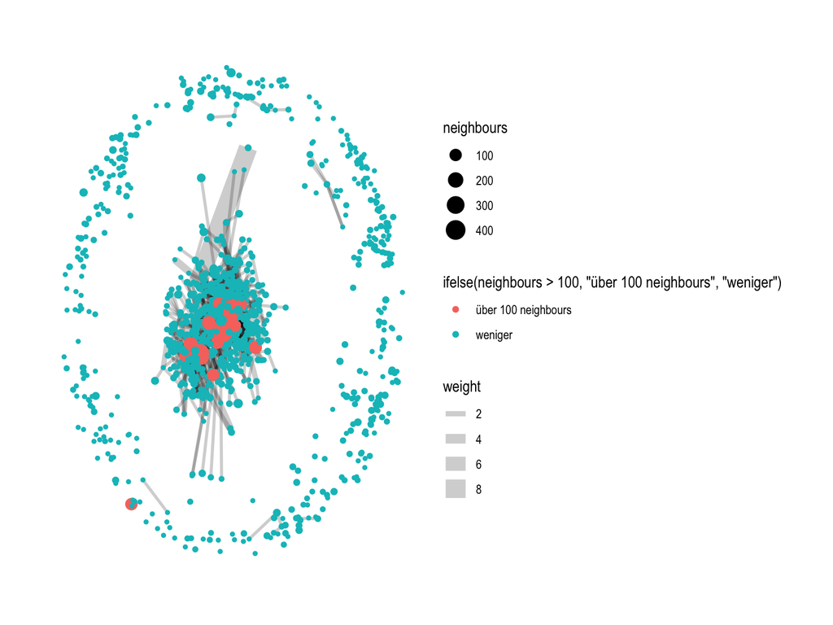

```r
metoo_activity_graph%>%
  activate(nodes)%>%
  filter(neighbours>0)%>%
  ggraph(.,layout="kk")+
  geom_edge_link(aes(width=weight),alpha= 0.2)+
  geom_node_point(aes(size=neighbours, color=ifelse(neighbours>100, "über 100 neighbours", "weniger")))+
  theme_graph()
```

Viele relevante Accounts befinden sich im Zentrum des Netzwerks. Ausnahmen von Accounts mit über 100 neighbours gibt es, wie beispielsweise “JuliaVanNixen” oder “patriarchator.”

[figure not shown]

```r
metoo_activity_graph%>%
  activate(nodes)%>%
  filter(neighbours>20)%>%
  ggraph(.,layout="kk")+
  geom_edge_link(aes(width=weight),alpha= 0.2)+
  geom_node_point(aes(size=neighbours, color=ifelse(neighbours>100, "über 100 neighbours", "weniger")))+
  geom_node_text(aes(label= ifelse(neighbours>100, name, "")), size= 3)+
  theme_graph()+
  theme(legend.position = "none")
```

```r
nodes_metoo%>%
  count(cluster)
```

```
## # A tibble: 637 × 2
##    cluster     n
##      <int> <int>
##  1       1   360
##  2       2   257
##  3       3   222
##  4       4   199
##  5       5   193
##  6       6   155
##  7       7   125
##  8       8   109
##  9       9   103
## 10      10   102
## # … with 627 more rows
```

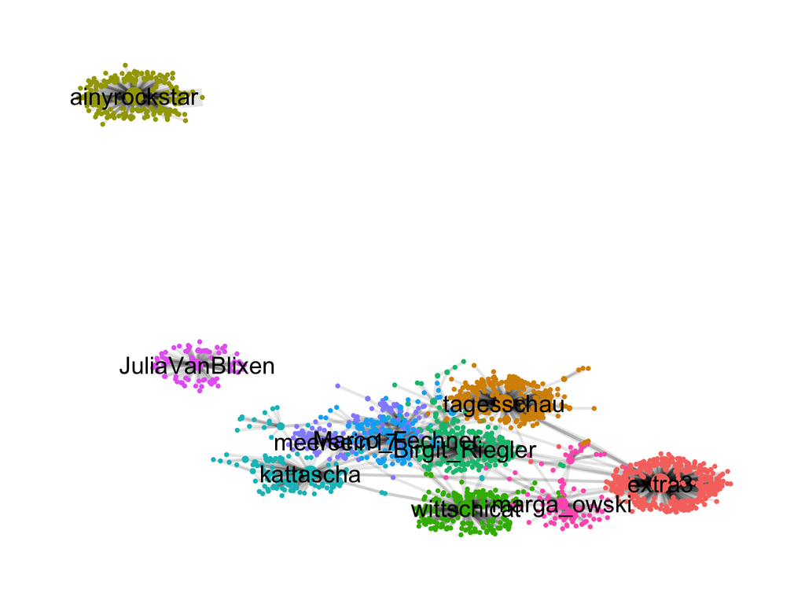

```r
metoo_activity_graph%>%
  activate(nodes)%>%
  filter(cluster<11)%>%
  ggraph(.,layout="fr")+
  geom_edge_link(aes(width=weight),alpha=0.1,show.legend = F)+
   geom_node_point(aes(color =factor(cluster), size=neighbours))+
  geom_node_text(aes(label= ifelse(neighbours>100,name,"")), size= 6,show.legend = F,repel = F)+
  theme_graph()+
    theme(legend.position = "none")
```

```r
nodes_metoo%>%
  filter(name== "JuliaVanBlixen"  | name== "ainyrockstar")
```

```
## # A tibble: 2 × 3
##   name           neighbours cluster
##   <chr>               <dbl>   <int>
## 1 ainyrockstar          338       3
## 2 JuliaVanBlixen        102       9
```

```r
nodes_metoo%>%
  filter(neighbours>100)
```

```
## # A tibble: 21 × 3
##    name           neighbours cluster
##    <chr>               <dbl>   <int>
##  1 deinTherapeut         128      16
##  2 kattascha             232       6
##  3 Marco_Fechner         217       7
##  4 patriarchator         135      19
##  5 extra3                450       1
##  6 Birgit_Riegler        268       5
##  7 ainyrockstar          338       3
##  8 marga_owski           120      10
##  9 habichthorn           106      21
## 10 InaRuck               115      22
## # … with 11 more rows
```

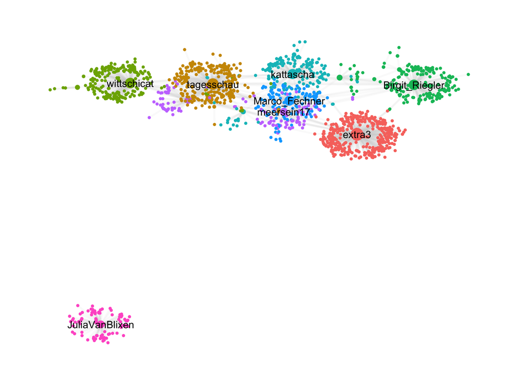

```r
metoo_activity_graph%>%
  activate(nodes)%>%
  filter(cluster<11)%>%
  filter(cluster!= 3 & cluster != 10)%>%
  ggraph(.,layout="fr")+
  geom_edge_link(aes(width=weight),alpha=0.1,show.legend = F, color= "lightgrey")+
   geom_node_point(aes(color =factor(cluster), size=neighbours))+
  geom_node_text(aes(label= ifelse(neighbours>100,name,"")), size= 4)+
  theme_graph()+
    theme(legend.position = "none")
```

Interessant ist, dass alle Accounts über 100 neighbours in verschiedenen Clustern sind. Das geht aus vorangegangenen Rechnungen hervor. Diese Beobachtung spiegelt sich auch in der Visualisierung wider. Die relevantesten Accounts befinden sich in der Mitte ihres jeweiligen Clusters und sind sozusagen Alleinherrscher über die vorherrschende Meinung in demselben. Die Cluster rund um “extra3” sowie “Birgit_Riegler” scheinen weiter abgekapselt von dem Zentrum des Meinungsaustausches zu sein, da weniger links erkennbar sind. Letztere ist Redakteurin für “derstandard.at.” Während sich die “Tagesschau” noch am Rande des Zentrums befindet, sind die führenden Accounts primär Privatkonten. Auf diese Twitteraccounts soll nun ein genauerer Blick geworfen werden: Sind diese auch nach dem Aufkommen der #metoo Debatte populär? Und wie viel Mühe geben sie sich, auf Twitter aktiv zu sein?

# Analyse der einflussreichsten Twitteraccounts

Wer sind diese Menschen, die sowohl die häufigsten Retweets haben als auch in großen Clustern eine Rolle spielen? Sind die schon zuvor einflussreich gewesen? Wie aktiv sind die auf Twitter?

```r
#lade Pakete
library(rtweet)
devtools::install_github("gadenbuie/tweetrmd")
devtools::install_github("gadenbuie/tweetrmd")
library(tidytext)
library(gridExtra)
#sichere api keys
 api_key<- "FmqpHUvDb0OUFdOdHX4oA1F0r"
 api_secret <- "gSg3dF4txK4K5eCaoH90N580hEbQKYS722dOwMRY6885Cgaco7"
 access_token <- "2207998455-1tjd6URw5rM37Kd4peXVHAQ2eLHwibiOCFTgGw9"
 access_secret<- "mfouq1jD2JnLwDhteLGonmxxRkkWLkWHN5Jd0HBwNBvqM"

#Erstellung des tokens

 token <- create_token(
   app="metooapp",
   consumer_key = api_key,
   consumer_secret = api_secret,
   access_token = access_token,
   access_secret = access_secret
 )

# Timelines ziehen home= T,parse=T,
marco_fechner<- get_timeline("PankowerPflanze",  n=1000)
meersein17<- get_timeline("meersein17", n=1000)
klaassenbeste<- get_timeline("klaassenbeste",  n=1000)
kattascha<- get_timeline("kattascha", n=1000)
wittschicat<- get_timeline("wittschicat",  n=1000)
```

Bis auf klaassenbeste gibt es alle Accounts noch. Anmerkung: Marco Fechner= PankowerPflanze

# Aktivität beobachten

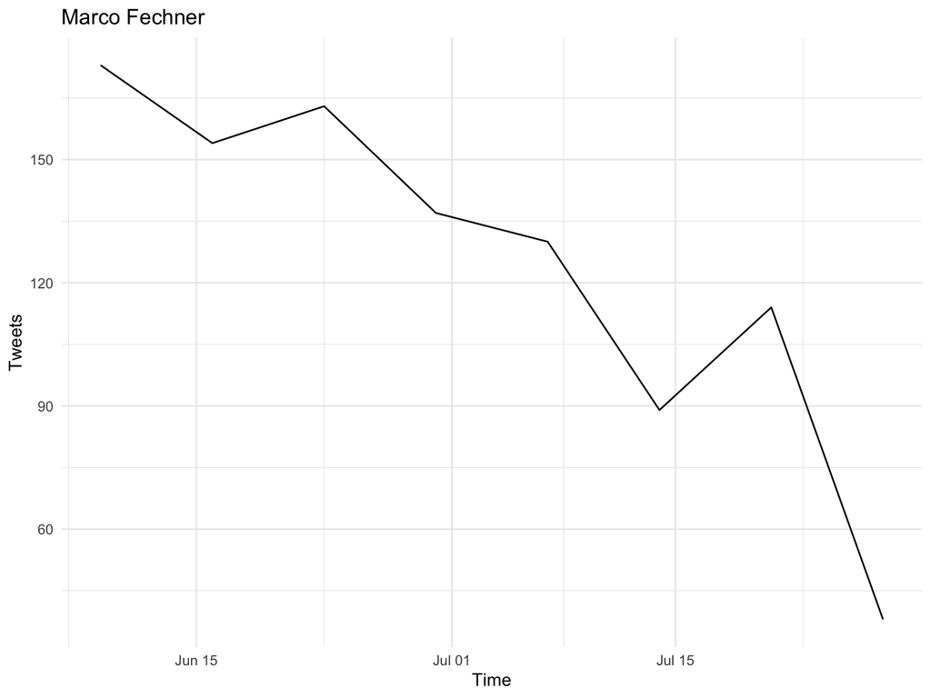

```r
p1<-  ts_plot(marco_fechner, "weeks")+
  labs(y="Tweets", x="Time", title="Marco Fechner")+
  theme_minimal()
p1
```

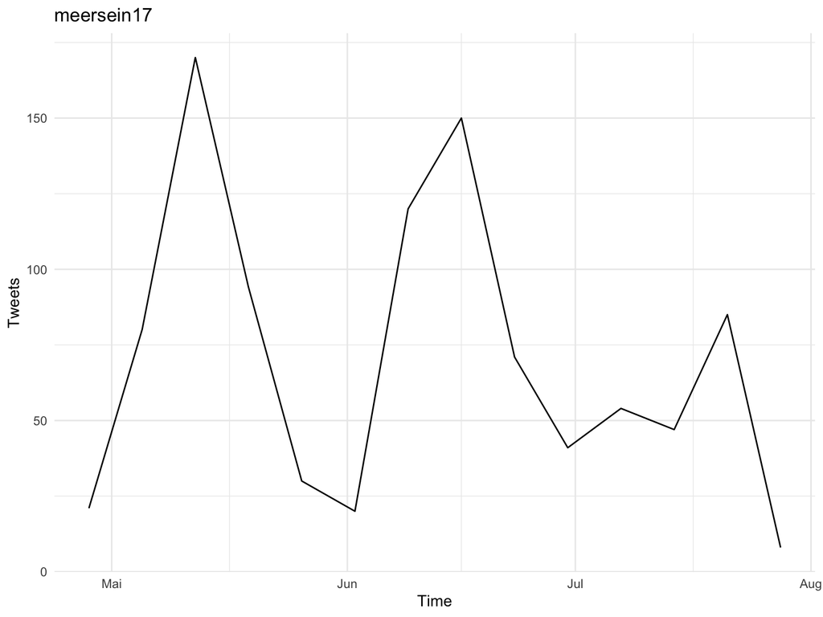

```r
p2<- ts_plot(meersein17, "weeks")+
  labs(y="Tweets", x="Time", title="meersein17")+
  theme_minimal()
p2
```

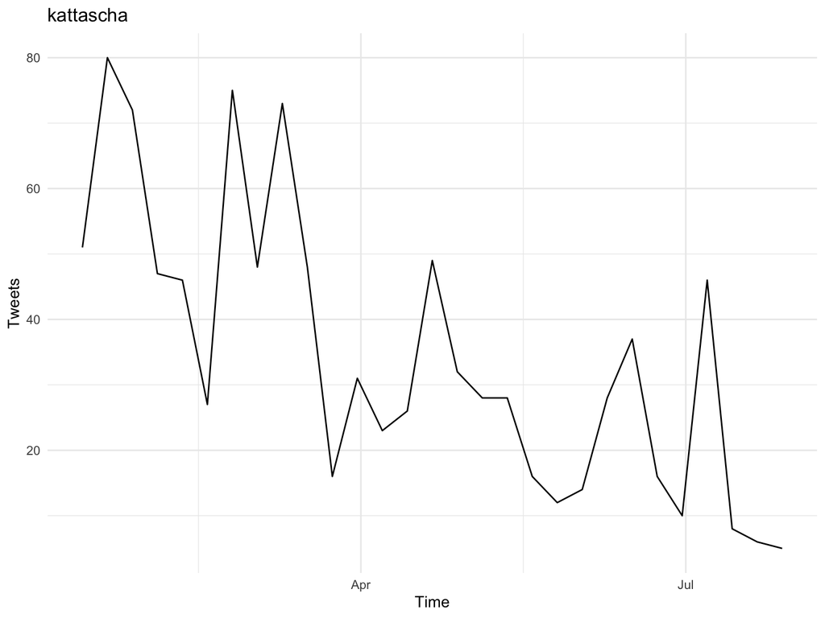

```r
p3<- ts_plot(kattascha, "weeks")+
  labs(x="Time", y="Tweets", title="kattascha")+
  theme_minimal()
p3
```

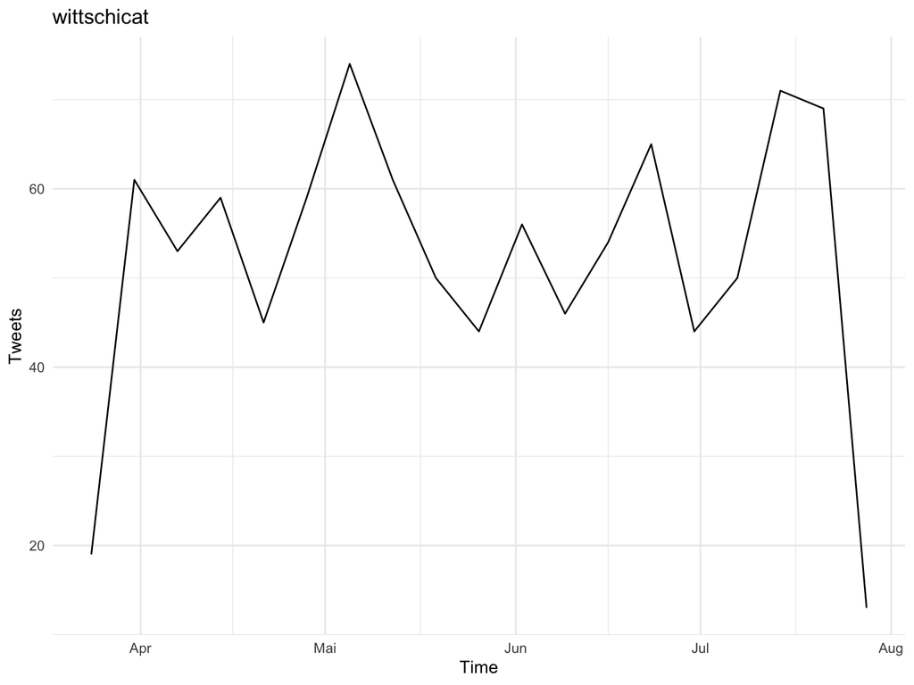

```r
p4<- ts_plot(wittschicat, "weeks")+
  labs(y="Tweets", x="Time", title="wittschicat")+
  theme_minimal()
p4
```